# Week 10 Tutorial

ECON90033 - 2023 Semester 2

Josh Copeland

Completed on 16 October 2023

## Exercise 1

### a) Import the data set. and attach it to your R project. Construct the rate of inflation rate (p_t) and the growth rate of money supply (m_t). Plot these variables and briefly comment on the figures.

Both series look like they fluctuate around some constant mean

```r
e1 <- read_excel("C:/Users/joshc/Documents/2023S2/ECON90033/Tutorials/Week 10/t10e1.xlsx")
```

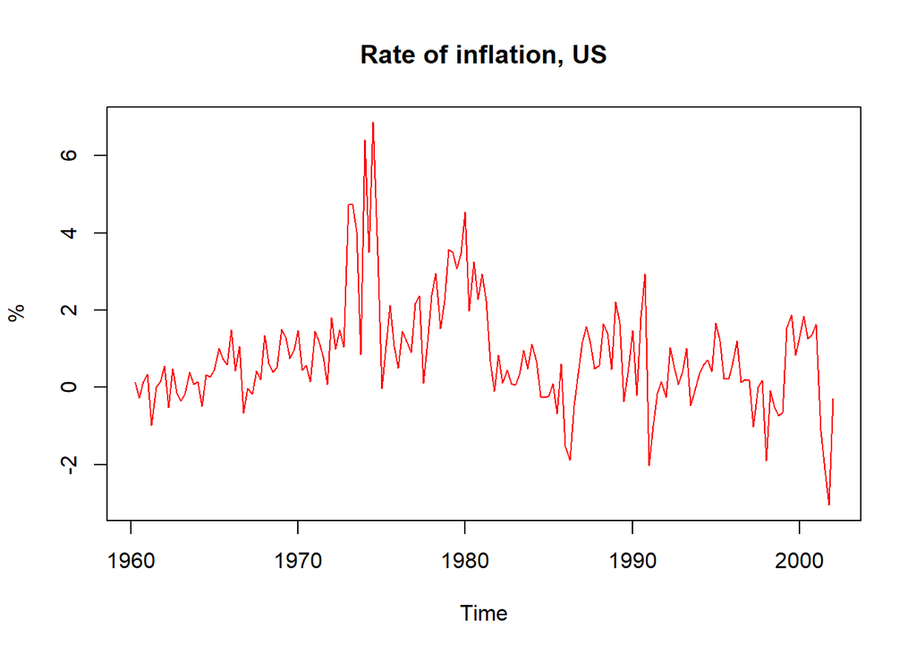

```r
ppi <- e1 %>%
  pull(ppi) %>%
  ts(start = c(1960,1), end = c(2002,1), frequency = 4)

m1 <- e1 %>%
  pull(m1) %>%
  ts(start = c(1960,1), end = c(2002,1), frequency = 4)

p <- 100*diff(log(ppi))

m <- 100*diff(log(m1))

plot(p, main = "Rate of inflation, US", col = "red", ylab = "%")
```

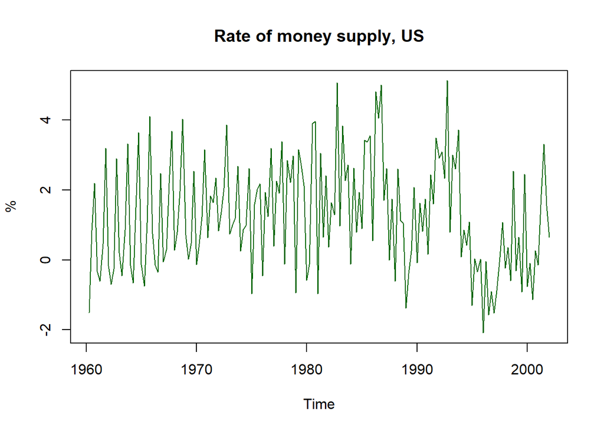

```r
plot(m, main = "Rate of money supply, US", col = "darkgreen", ylab = "%")
```

### b) Perform the ADF and KPSS tests on the levels and first differences of p and m. What conclusions do you draw from these tests about the order of integration of these variables?

```r
library(urca)

#ADF tests

adf_p <- ur.df(p, type = "drift", selectlags = "BIC")
summary(adf_p)
```

```
##
## ###############################################
## # Augmented Dickey-Fuller Test Unit Root Test #
## ###############################################
##
## Test regression drift
##
##
## Call:
## lm(formula = z.diff ~ z.lag.1 + 1 + z.diff.lag)
##
## Residuals:
##     Min      1Q  Median      3Q     Max
## -4.0715 -0.5148 -0.0087  0.5145  4.9016
##
## Coefficients:
##             Estimate Std. Error t value Pr(>|t|)
## (Intercept)  0.25968    0.10461   2.482  0.01406 *
## z.lag.1     -0.31151    0.06904  -4.512 1.22e-05 ***
## z.diff.lag  -0.20866    0.07866  -2.653  0.00878 **
## ---
## Signif. codes:  0 '***' 0.001 '**' 0.01 '*' 0.05 '.' 0.1 ' ' 1
##
## Residual standard error: 1.112 on 163 degrees of freedom
## Multiple R-squared:  0.2314, Adjusted R-squared:  0.222
## F-statistic: 24.54 on 2 and 163 DF,  p-value: 4.82e-10
##
##
## Value of test-statistic is: -4.512 10.1825
##
## Critical values for test statistics:
##       1pct  5pct 10pct
## tau2 -3.46 -2.88 -2.57
## phi1  6.52  4.63  3.81
```

```r
adf_d_p <- ur.df(diff(p), type = "drift", selectlags = "BIC")
summary(adf_d_p)
```

```
##
## ###############################################
## # Augmented Dickey-Fuller Test Unit Root Test #
## ###############################################
##
## Test regression drift
##
##
## Call:
## lm(formula = z.diff ~ z.lag.1 + 1 + z.diff.lag)
##
## Residuals:
##     Min      1Q  Median      3Q     Max
## -4.1700 -0.4760  0.0253  0.6061  3.9097
##
## Coefficients:
##             Estimate Std. Error t value Pr(>|t|)
## (Intercept) -0.01390    0.08909  -0.156  0.87623
## z.lag.1     -1.72205    0.12732 -13.525  < 2e-16 ***
## z.diff.lag   0.25595    0.07713   3.318  0.00112 **
## ---
## Signif. codes:  0 '***' 0.001 '**' 0.01 '*' 0.05 '.' 0.1 ' ' 1
##
## Residual standard error: 1.144 on 162 degrees of freedom
## Multiple R-squared:  0.6996, Adjusted R-squared:  0.6959
## F-statistic: 188.7 on 2 and 162 DF,  p-value: < 2.2e-16
##
##
## Value of test-statistic is: -13.5251 91.4738
##
## Critical values for test statistics:
##       1pct  5pct 10pct
## tau2 -3.46 -2.88 -2.57
## phi1  6.52  4.63  3.81
```

```r
adf_m <- ur.df(m, type = "drift", selectlags = "BIC")
summary(adf_m)
```

```
##
## ###############################################
## # Augmented Dickey-Fuller Test Unit Root Test #
## ###############################################
##
## Test regression drift
##
##
## Call:
## lm(formula = z.diff ~ z.lag.1 + 1 + z.diff.lag)
##
## Residuals:
##     Min      1Q  Median      3Q     Max
## -3.0581 -1.2446 -0.0843  1.2230  3.7070
##
## Coefficients:
##             Estimate Std. Error t value Pr(>|t|)
## (Intercept)  0.89610    0.17496   5.122 8.47e-07 ***
## z.lag.1     -0.69388    0.10000  -6.939 8.84e-11 ***
## z.diff.lag  -0.18883    0.07622  -2.477   0.0143 *
## ---
## Signif. codes:  0 '***' 0.001 '**' 0.01 '*' 0.05 '.' 0.1 ' ' 1
##
## Residual standard error: 1.538 on 163 degrees of freedom
## Multiple R-squared:  0.448,  Adjusted R-squared:  0.4412
## F-statistic: 66.13 on 2 and 163 DF,  p-value: < 2.2e-16
##
##
## Value of test-statistic is: -6.9391 24.0783
##
## Critical values for test statistics:
##       1pct  5pct 10pct
## tau2 -3.46 -2.88 -2.57
## phi1  6.52  4.63  3.81
```

```r
adf_d_m <- ur.df(diff(m), type = "drift", selectlags = "BIC")
summary(adf_d_m)
```

```
##
## ###############################################
## # Augmented Dickey-Fuller Test Unit Root Test #
## ###############################################
##
## Test regression drift
##
##
## Call:
## lm(formula = z.diff ~ z.lag.1 + 1 + z.diff.lag)
##
## Residuals:
##     Min      1Q  Median      3Q     Max
## -4.0045 -1.2959  0.0167  1.0056  4.1007
##
## Coefficients:
##               Estimate Std. Error t value Pr(>|t|)
## (Intercept) -0.0001514  0.1325370  -0.001  0.99909
## z.lag.1     -1.8748492  0.1338896 -14.003  < 2e-16 ***
## z.diff.lag   0.2172331  0.0762897   2.847  0.00498 **
## ---
## Signif. codes:  0 '***' 0.001 '**' 0.01 '*' 0.05 '.' 0.1 ' ' 1
##
## Residual standard error: 1.702 on 162 degrees of freedom
## Multiple R-squared:  0.7816, Adjusted R-squared:  0.7789
## F-statistic: 289.9 on 2 and 162 DF,  p-value: < 2.2e-16
##
##
## Value of test-statistic is: -14.0029 98.0695
##
## Critical values for test statistics:
##       1pct  5pct 10pct
## tau2 -3.46 -2.88 -2.57
## phi1  6.52  4.63  3.81
```

```r
#KPSS tests

kpss_p = ur.kpss(p, type = "mu")
summary(kpss_p)
```

```
##
## #######################
## # KPSS Unit Root Test #
## #######################
##
## Test is of type: mu with 4 lags.
##
## Value of test-statistic is: 0.4726
##
## Critical value for a significance level of:
##                 10pct  5pct 2.5pct  1pct
## critical values 0.347 0.463  0.574 0.739
```

```r
kpss_d_p = ur.kpss(diff(p), type = "mu")
summary(kpss_d_p)
```

```
##
## #######################
## # KPSS Unit Root Test #
## #######################
##
## Test is of type: mu with 4 lags.
##
## Value of test-statistic is: 0.0306
##
## Critical value for a significance level of:
##                 10pct  5pct 2.5pct  1pct
## critical values 0.347 0.463  0.574 0.739
```

```r
kpss_m = ur.kpss(m, type = "mu")
summary(kpss_m)
```

```
##
## #######################
## # KPSS Unit Root Test #
## #######################
##
## Test is of type: mu with 4 lags.
##
## Value of test-statistic is: 0.3429
##
## Critical value for a significance level of:
##                 10pct  5pct 2.5pct  1pct
## critical values 0.347 0.463  0.574 0.739
```

```r
kpss_d_m = ur.kpss(diff(m), type = "mu")
summary(kpss_d_m)
```

```
##
## #######################
## # KPSS Unit Root Test #
## #######################
##
## Test is of type: mu with 4 lags.
##
## Value of test-statistic is: 0.0348
##
## Critical value for a significance level of:
##                 10pct  5pct 2.5pct  1pct
## critical values 0.347 0.463  0.574 0.739
```

### c) Consider a VAR model with a constant of p and m, and determine the optimal lag length

with the VARselect() function of the vars package.

The output below tells us HQ and SC take their smallest values at 5 lags, whereas its 10 lags for AIC and FPE.

Start with the 5-lag model and then test the residuals for first and second order autocorrelation using the Breusch-Godfrey (BG) LM test.

Given the large p-value (0.51), we maintain the null hypothesis ther there is not first and second order residual serial autocorrelation and accept the VAR(5) model.

```r
#library(vars)

data <- cbind(p,m)

VARselect(data, type = "const")
```

```
## $selection
## AIC(n)  HQ(n)  SC(n) FPE(n)
##     10      5      5     10
##
## $criteria
##               1        2        3         4         5         6         7
## AIC(n) 1.195658 1.125373 1.143558 0.6106545 0.4474812 0.4819956 0.4784176
## HQ(n)  1.242890 1.204092 1.253765 0.7523485 0.6206628 0.6866647 0.7145743
## SC(n)  1.311959 1.319208 1.414927 0.9595577 0.8739185 0.9859669 1.0599230
## FPE(n) 3.305764 3.081496 3.138278 1.8420912 1.5650730 1.6205106 1.6153711
##                8         9        10
## AIC(n) 0.4552138 0.4160713 0.4125227
## HQ(n)  0.7228581 0.7152030 0.7431420
## SC(n)  1.1142533 1.1526448 1.2266302
## FPE(n) 1.5791493 1.5195439 1.5154113
```

```r
var5 <- VAR(data, p = 5, type = "const")

serial.test(var5, lags.bg = 2, type = "BG")
```

```
##
##  Breusch-Godfrey LM test
##
## data:  Residuals of VAR object var5
## Chi-squared = 7.2637, df = 8, p-value = 0.5085
```

Below we can see a breakdown of the VAR model printout:

- The first part shows, among other things, the lengths of the estimated characteristic roots. As this is a bivariate system with 5 lags, there are 10 characteristic roots.As the absolute values of their points estimates are all smaller than 1, we conclude this VAR is stable.
- The second part shows the two estimated equations of the VAR(5). Both are acceptable as they are strongly significant and have reasonable adjusted R^2 values.
  - However, there are also many insignificant t ratios. This is not unusual in VAR models, and it is not an isue because in VAR analyses the individual coefficients are of little importance.

```r
summary(var5)
```

```
##
## VAR Estimation Results:
## =========================
## Endogenous variables: p, m
## Deterministic variables: const
## Sample size: 163
## Log Likelihood: -474.151
## Roots of the characteristic polynomial:
## 0.9612 0.9255 0.9243 0.9243 0.7266 0.7266 0.6083 0.6083 0.5751 0.02102
## Call:
## VAR(y = data, p = 5, type = "const")
##
##
## Estimation results for equation p:
## ==================================
## p = p.l1 + m.l1 + p.l2 + m.l2 + p.l3 + m.l3 + p.l4 + m.l4 + p.l5 + m.l5 + const
##
##       Estimate Std. Error t value Pr(>|t|)
## p.l1   0.42719    0.07999   5.341 3.32e-07 ***
## m.l1  -0.01141    0.07446  -0.153   0.8784
## p.l2   0.13541    0.08767   1.545   0.1245
## m.l2   0.11578    0.05636   2.055   0.0416 *
## p.l3   0.11144    0.08712   1.279   0.2028
## m.l3   0.07521    0.05712   1.317   0.1899
## p.l4   0.17996    0.08651   2.080   0.0392 *
## m.l4  -0.08942    0.05754  -1.554   0.1222
## p.l5  -0.10288    0.08250  -1.247   0.2143
## m.l5   0.08774    0.07550   1.162   0.2470
## const -0.01918    0.15937  -0.120   0.9043
## ---
## Signif. codes:  0 '***' 0.001 '**' 0.01 '*' 0.05 '.' 0.1 ' ' 1
##
##
## Residual standard error: 1.076 on 152 degrees of freedom
## Multiple R-Squared: 0.4605,  Adjusted R-squared: 0.425
## F-statistic: 12.97 on 10 and 152 DF,  p-value: 3.256e-16
##
##
## Estimation results for equation m:
## ==================================
```

[output cut: 18 more lines]

```
## Residual standard error: 1.07 on 152 degrees of freedom
## Multiple R-Squared: 0.5671,  Adjusted R-squared: 0.5386
## F-statistic: 19.91 on 10 and 152 DF,  p-value: < 2.2e-16
##
##
##
## Covariance matrix of residuals:
##           p         m
## p  1.158061 -0.001948
## m -0.001948  1.144586
##
## Correlation matrix of residuals:
##           p         m
## p  1.000000 -0.001692
## m -0.001692  1.000000
```

### d) Use the estimated VAR(5) model to forecast p and m 1- 4 quarters ahead.

The plots below show that the 80% and 95% prediction bands are both very wide, showing that the point predictions are of little precision.

```r
#library(forecast)

var5_ea <- forecast(var5, h = 4)

print(var5_ea)
```

```
## p
##         Point Forecast     Lo 80     Hi 80     Lo 95    Hi 95
## 2002 Q2     -0.9192595 -2.298379 0.4598596 -3.028440 1.189921
## 2002 Q3     -1.0296777 -2.529458 0.4701027 -3.323394 1.264038
## 2002 Q4     -0.4549721 -2.025189 1.1152450 -2.856412 1.946468
## 2003 Q1      0.4337493 -1.199049 2.0665476 -2.063400 2.930899
##
## m
##         Point Forecast       Lo 80    Hi 80      Lo 95    Hi 95
## 2002 Q2     2.78926909  1.41819705 4.160341  0.6923954 4.886143
## 2002 Q3     3.08278112  1.63250881 4.533053  0.8647810 5.300781
## 2002 Q4     1.45645420 -0.03302575 2.945934 -0.8215088 3.734417
## 2003 Q1     0.08911688 -1.41868065 1.596914 -2.2168605 2.395094
```

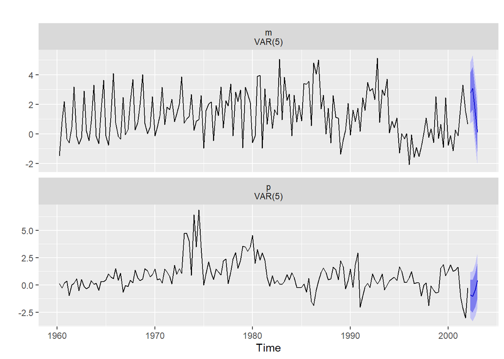

```r
autoplot(var5_ea)
```

### e) Use the estimated VAR(5) model to test for Granger causality between p and m at the 5% significance level.

Before getting into the question, a brief recap of Granger causality:

- For two stationary variables Y and Z, Z is asid to be Granger causal to Y if and only if Y_t+1 can be predicted better when the information set includes Z_t, Z_t-1 etc.
- If both variables are Granger causal to each other, there is a two-way (or feedback) Granger causal relationship between the two variables.

When we set up a VAR model, the LGS variables are considered endogenous variables. However, Granger causality tests allow is to explicitly test if they are empirically endogenous within the defined system of a model.

A variable is an endogenous variable in the given sytem if the other variables jointly Granger cause it. Otherwise, it is exogenous.

This relationship is tested with a general F-test or the Wald chi-square test on all lags of a variable (or several variables jointly).

Under the null hypothesis, all these lags have zero coefficients. In the alternate hypothesis, some lag(s) has (have) non-zero coefficient(s).

Looking at the granger causality test for the VAR model of the inflation rate and rate of growth in the money supply we can see:

- At the 5% level both tests indicate that m is not causing p (i.e. m -> p) and that p is causing m (i.e. m -> p)
- However, at the 10% level, both tests indicated a two-way (feedback) Granger causal relationship between them (i.e. p <-> m)

Often you might get contradicting or ambiguous test results. In this case you might need to make a call about whether to use the F or Chi-square test. To make this call remember: F tests assume normality whereas Chi-square does not.

```r
# library(bruceR)

granger_causality(var5)
```

```
##
## Granger Causality Test (Multivariate)
##
## F test and Wald χ² test based on VAR(5) model:
## ──────────────────────────────────────────────────────
##                 F df1 df2     p     Chisq df     p
## ──────────────────────────────────────────────────────
##  --------
##  p <= m      2.13   5 152  .065 .   10.64  5  .059 .
##  p <= ALL    2.13   5 152  .065 .   10.64  5  .059 .
##  --------
##  m <= p      4.00   5 152  .002 **  20.02  5  .001 **
##  m <= ALL    4.00   5 152  .002 **  20.02  5  .001 **
## ──────────────────────────────────────────────────────
```

After estimating a VAR model, multivariate Jarque-Bera tests and multivariate skewness and kurtosis tests need to be performed. This compares the skewness and kurtosis statistics to the skewness and kurtosis paramters of a multivariate normal distributions whose expected valeus and standard deviations are equal to the corresponding sample means and sample standard deviations.

To interpret the output:

- the p-value of the multivariate JB test is practically zero, so the null hypothesis of normality can be safely rejected.
- the middle and bottom part of this prinout focus on the two crucial componentso f the JB test: skewness and kurtosis:
  - The p-value for skewness is large (0.52), therefore in terms of skewness the residuals might be normally distributed.
  - The p-value of kurtossis is practically zero. Therefore, the kurtossis of the residuals are not normally distributed. Therefore that’s why the JB test rejects normality.

```r
normality.test(var5)
```

```
## $JB
##
##  JB-Test (multivariate)
##
## data:  Residuals of VAR object var5
## Chi-squared = 133.07, df = 4, p-value < 2.2e-16
##
##
## $Skewness
##
##  Skewness only (multivariate)
##
## data:  Residuals of VAR object var5
## Chi-squared = 1.3049, df = 2, p-value = 0.5208
##
##
## $Kurtosis
##
##  Kurtosis only (multivariate)
##
## data:  Residuals of VAR object var5
## Chi-squared = 131.76, df = 2, p-value < 2.2e-16
```